# The Project

1. This is a project with minimal scaffolding. Expect to use the the discussion forums to gain insights! It’s not cheating to ask others for opinions or perspectives!
2. Be inquisitive, try out new things.
3. Use the previous modules for insights into how to complete the functions! You'll have to combine Pillow, OpenCV, and Pytesseract
4. There are hints provided in Coursera, feel free to explore the hints if needed. Each hint provide progressively more details on how to solve the issue. This project is intended to be comprehensive and difficult if you do it without the hints.

### The Assignment

Take a ZIP file) of images and process them, using a [library built into python](https://docs.python.org/3/library/zipfile.html) that you need to learn how to use. A ZIP file takes several different files and compresses them, thus saving space, into one single file. The files in the ZIP file we provide are newspaper images (like you saw in week 3). Your task is to write python code which allows one to search through the images looking for the occurrences of keywords and faces. E.g. if you search for "pizza" it will return a contact sheet of all of the faces which were located on the newspaper page which mentions "pizza". This will test your ability to learn a new ([library](https://docs.python.org/3/library/zipfile.html)), your ability to use OpenCV to detect faces, your ability to use tesseract to do optical character recognition, and your ability to use PIL to composite images together into contact sheets.

Each page of the newspapers is saved as a single PNG image in a file called images.zip. These newspapers are in english, and contain a variety of stories, advertisements and images. Note: This file is fairly large (~200 MB) and may take some time to work with, I would encourage you to use small_img.zip for testing.

Here's an example of the output expected. Using the small_img.zip file, if I search for the string "Christopher" I should see the following image:

[figure not shown]

If I were to use the images.zip file and search for "Mark" I should see the following image (note that there are times when there are no faces on a page, but a word is found!):

[figure not shown]

Note: That big file can take some time to process - for me it took nearly ten minutes! Use the small one for testing.

```python
import zipfile

from PIL import Image
import pytesseract
import cv2 as cv
import numpy as np
from IPython.display import display

# loading the face detection classifier
face_cascade = cv.CascadeClassifier('readonly/haarcascade_frontalface_default.xml')

# the rest is up to you!
```

# Using Small image file

```python
# Using small image files as instructed

images_newspaper = []

def print_newspaper(zipped_newspaper, c = 1):
    z_file = zipfile.ZipFile(zipped_newspaper)
    for info in z_file.infolist():
        with z_file.open(info) as file:
            Image.open(file).convert("RGB").save("image" + "_" + str(c) + ".jpg")
            images_newspaper.append("image" + "_" + str(c) + ".jpg")
            c += 1

print_newspaper("readonly/small_img.zip")
```

```python
def binarize(input_image, threshold):
    output_image = input_image.convert("L")

    for x in range(output_image.width):
        for y in range(output_image.height):
            if output_image.getpixel((x,y)) < threshold:
                output_image.putpixel((x,y), 0)

            else:
                output_image.putpixel((x,y), 255)

    return output_image
```

```python
'''
for image in images_newspaper:
    print(str(image))
    for limit in range(50,256, 51):
        print("Threshold: {}".format(limit))

        display(binarize(Image.open(image), limit))

        print(pytesseract.image_to_string(binarize(Image.open(image), limit)))

        print("\n")
'''
```

[output not shown]

```python
# Suitable threshold I found to be 200 after performing long analysis with multiple range of threshold value

image_text_dict = {}

for image in images_newspaper:
    image_text_dict[image] = pytesseract.image_to_string(binarize(Image.open(image), 200))

for key, value in image_text_dict.items():
    image_text_dict[key] = (str(image_text_dict[key]).replace("\n", ""))
```

```python
import PIL
import numpy as np

def find_face(image):
    cv_image = cv.imread(image)

    faces = face_cascade.detectMultiScale(cv_image, 1.350)

    if np.any(faces) == True:
        cropped_images = []
        for x,y,w,h in faces:
            bounding_box = (x,y,w+x,h+y)
            face_image = Image.open(image).crop(bounding_box).resize((200,200))
            cropped_images.append(face_image)

        first_image=cropped_images[0]
        contact_sheet=PIL.Image.new(first_image.mode, (first_image.width*5,(first_image.height-120)*5))
        x = 0
        y = 0

        for img in cropped_images:
            contact_sheet.paste(img, (x, y))

            if x + first_image.width == contact_sheet.width:
                x = 0
                y = y + first_image.height

            else:
                x = x + first_image.width

        contact_sheet = contact_sheet.resize((int(contact_sheet.width/2),int(contact_sheet.height/2)))
        display(contact_sheet)

    else:
        print("But there were no faces in that file!")
```

```python
img_name_map = {'image_1.jpg':'a-0.png','image_2.jpg': 'a-1.png', 'image_3.jpg': 'a-2.png', 'image_4.jpg': 'a-3.png'}
archive_list = []
a_dictionary = {}

def find_string(string):


    for key, value in image_text_dict.items():

        try:
            if string.lower() in str(image_text_dict[key]).lower():
                print("Results found in file {}".format(img_name_map[key]))
                find_face(key)
                a_dictionary[img_name_map[key]]=Image.open(key),contact_sheet,string
                archive_list.append(a_dictionary)

            else:
                continue

        except Exception as ex:
                print(ex)
```

```
Results found in file a-0.png
```

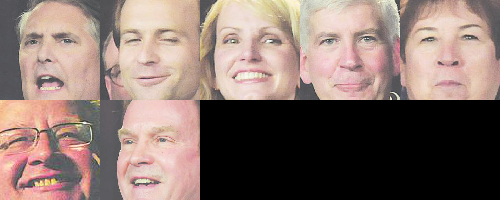

```
Results found in file a-3.png
```

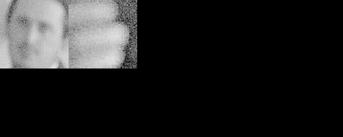

```python
find_string("Christopher")
```

# Using image file

```python
images_newspaper = []

def print_newspaper(zipped_newspaper, c = 1):
    z_file = zipfile.ZipFile(zipped_newspaper)
    for info in z_file.infolist():
        with z_file.open(info) as file:
            Image.open(file).convert("RGB").save("image" + "_" + str(c) + ".jpg")
            images_newspaper.append("image" + "_" + str(c) + ".jpg")
            c += 1

print_newspaper("readonly/images.zip")
```

```python
image_text_dict1 = {}

for image in images_newspaper:
    image_text_dict1[image] = pytesseract.image_to_string(binarize(Image.open(image), 200))

for key, value in image_text_dict1.items():
    image_text_dict1[key] = (str(image_text_dict1[key]).replace("\n", ""))
```

```python
import PIL
import numpy as np

def find_face_1(image):
    cv_image = cv.imread(image)

    faces = face_cascade.detectMultiScale(cv_image, 1.35,5)

    if np.any(faces) == True:
        cropped_images = []
        for x,y,w,h in faces:
            bounding_box = (x,y,w+x,h+y)
            face_image = Image.open(image).crop(bounding_box).resize((200,200))
            cropped_images.append(face_image)

        first_image=cropped_images[0]
        contact_sheet=PIL.Image.new(first_image.mode, (first_image.width*5,(first_image.height-120)*5))
        x = 0
        y = 0

        for img in cropped_images:
            contact_sheet.paste(img, (x, y))

            if x + first_image.width == contact_sheet.width:
                x = 0
                y = y + first_image.height

            else:
                x = x + first_image.width

        contact_sheet = contact_sheet.resize((int(contact_sheet.width/2),int(contact_sheet.height/2)))
        display(contact_sheet)

    else:
        print("But there were no faces in that file!")
```

```python
img_name_map1 = {'image_1.jpg':'a-0.png','image_2.jpg': 'a-1.png', 'image_3.jpg': 'a-10.png', 'image_4.jpg': 'a-11.png',
               'image_5.jpg': 'a-12.png','image_6.jpg': 'a-13.png', 'image_7.jpg': 'a-2.png', 'image_8.jpg': 'a-3.png',
                'image_9.jpg': 'a-4.png', 'image_10.jpg': 'a-5png', 'image_11.jpg': 'a-6.png', 'image_12.jpg': 'a-7.png',
                'image_13.jpg': 'a-8.png', 'image_14.jpg': 'a-9.png'}


def find_string_new(string):


    for key, value in image_text_dict1.items():

        try:
            if string.lower() in str(image_text_dict1[key]).lower():
                print("Results found in file {}".format(img_name_map1[key]))
                find_face_1(key)

            else:
                continue

        except Exception as ex:
                print(ex)
```

```
Results found in file a-0.png
```

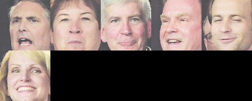

```
Results found in file a-1.png
```

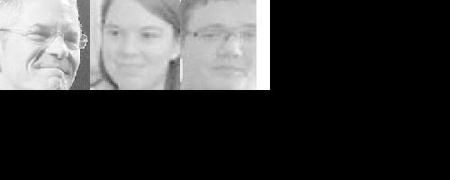

```
Results found in file a-10.png
But there were no faces in that file!
Results found in file a-13.png
```

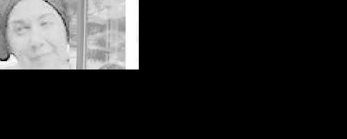

```
Results found in file a-2.png
```

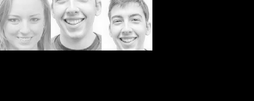

```
Results found in file a-3.png
```

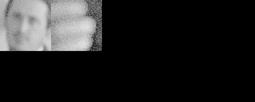

```
Results found in file a-5png
```

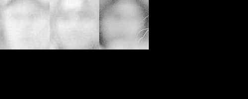

```
Results found in file a-8.png
But there were no faces in that file!
Results found in file a-9.png
```

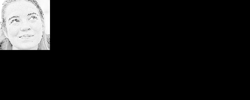

```python
find_string_new("Mark")
```